# Summary

### Summary

#### Fixed points

##### Model 1

\[ (x, y) = \left(\frac{f}{e}, \frac{ae - bf}{ce}\right) \]

##### Model 2

\[ (x, y) = \left(\frac{ag - cf}{ce + bg}, \frac{ae + bf}{ce + bg}\right) \]

#### Jacobian

The general Jaccobian is, \[ J = \begin{bmatrix} a-2bx - cy & -cx \\ ey & ex + f - 2gy \\ \end{bmatrix} \]

##### model II

\[ J = \begin{bmatrix} -bx & -cx \\ ey & - f - ex \\ \end{bmatrix} = \begin{bmatrix} -bx & -cx \\ ey & -gy \\ \end{bmatrix} \]

##### model I

\[ \begin{bmatrix} a - 2bx - cy & - cx \\ ey & - f \\ \end{bmatrix} = \begin{bmatrix} - bx & - cx \\ ey & - f \\ \end{bmatrix} \]

#### Trace determinant

Model 1

\[ \delta = bfx + cexy \]

\[ \tau = -bx - f \]

Model 2

\[ \delta = bx(f+ex) + cexy = (bg+ce)xy \]

### Models

We are required to analyze two models very similar models:

#### model I

\[ \frac{dx}{dt} = ax - bx^2 - cxy \] \[ \frac{dy}{dt} = exy - fy \]

#### model II

\[ \frac{dx}{dt} = ax - bx^2 - cxy \] \[ \frac{dy}{dt} = exy + fy - gy^2 \]

The similarity of these two models makes their analysis very similar. It suffices to analyze model II and then substitute in \(f < 0\) and \(g = 0\) for the analogous result for model I. Therefore, in every case we analyze model II first.

### Explanations

#### Verify that the prey follows a logistic model when the predator is rare

We may manipulate the prey equation, \[ \frac{dx}{dt} = ax\left(1 - \frac{b}{a}x\right) - cxy \] and then reparameterize, \[ \frac{dx}{dt} = rx\left(1 - \frac{x}{K}\right) - cxy \] where \(K = \frac{a}{b}\) is the carrying capacity and \(r = a\) is the prey growth rate when it is rare.

#### Verify the equations for model II

The predators now follow logistic growth, which by analogy with model I is achieved through the additional squared term for the predators.

### Fixed points

#### model II

At a fixed point we have, \[ ax = bx^2 + cxy \] \[ exy + fy = gy^2 \] which simplify to, \[ a = bx + cy \] \[ ex + f = gy \] for positive fixed points.

\[ x = \frac{a}{b} - \frac{c}{b}y = \frac{g}{e}y - \frac{f}{e} \] \[ \left(\frac{g}{e} + \frac{c}{b}\right)y = \frac{a}{b} + \frac{f}{e} \] \[ y = \frac{\frac{a}{b} + \frac{f}{e}}{\frac{g}{e} + \frac{c}{b}} \] \[ y = \frac{\frac{ae}{be} + \frac{bf}{be}}{\frac{bg}{be} + \frac{ce}{be}} \] \[ y = \frac{ae + bf}{bg + ce} \] \[ x = \frac{a}{b} - \frac{c}{b}y \] \[ x = \frac{a}{b} - \frac{c}{b}\frac{ae + bf}{bg + ce} \] \[ x = \frac{1}{b}\left(a - c\frac{ae + bf}{bg + ce}\right) \]

\[ x = \frac{1}{b}\left(\frac{abg + ace - ace - bcf}{bg + ce}\right) \]

\[ x = \left(\frac{ag - cf}{bg + ce}\right) \]

Therefore a nonzero fixed point is,

\[ (x, y) = \left(\frac{ag - cf}{ce + bg}, \frac{ae + bf}{ce + bg}\right) \]

The condition for positivity is therefore,

\[ ag > cf \]

That is, a positive fixed point for the prey requires that the prey growth rate, \(a\), and among-predator competition coefficient, \(g\), are large relative to the attack rate, \(c\), and the predator growth rate, \(f\), which makes sense.

### Stability

#### model II

The general Jaccobian is, \[ J = \begin{bmatrix} a-2bx - cy & -cx \\ ey & ex + f - 2gy \\ \end{bmatrix} \] \[ J = \begin{bmatrix} a-2bx - a +bx & -cx \\ ey & ex + f - 2f - 2ex \\ \end{bmatrix} \] \[ J = \begin{bmatrix} -bx & -cx \\ ey & - f - ex \\ \end{bmatrix} \]

The determinant is, \[ \delta = bx(f+ex) + cexy \] The trace is, \[ \tau = - f - (b + e)x \] \[ 4bx(f+ex) + 4cexy > (f + (b + e)x)^2 \]

It helps to eliminate \(y\) (or \(x\), but we will do \(y\)) along the diagonal, using the intermediate steps obtained when finding the fixed points. \[ J = \begin{bmatrix} a-2bx - a + bx & -cx \\ ey & gy - 2gy \\ \end{bmatrix} \] which leads to, \[ J = \begin{bmatrix} -bx & -cx \\ ey & -gy \\ \end{bmatrix} \]

#### model I

We are required to find a positive fixed point. The second equation looks easier, so we set \(\frac{dy}{dt} = 0\) to find, \[ exy = fy \] Assuming \(y > 0\) means we can divide by \(y\) to obtain, \[ ex = f \] which we rearrange, \[ x = \frac{f}{e} \]

The first equation leads to, \[ ax = bx^2 + cxy \] Again because of positivity we divide by \(x\), \[ a = bx + cy \] Substituting in the expression for \(x\) gives, \[ a = \frac{bf}{e} + cy \] Solving, \[ y = \frac{a}{c} - \frac{bf}{ce} \] and rearranging leads to, \[ y = \frac{ae - bf}{ce} \]

Therefore the fixed point is, \[ (x, y) = \left(\frac{f}{e}, \frac{ae - bf}{ce}\right) \] Positivity requires that, \[ ae > bf \]

The Jaccobian is,

\[ \begin{bmatrix} a - 2bx - cy & - cx \\ ey & - f \\ \end{bmatrix} \]

We can substitute in \(cy = a - bx\) from an intermediate step in the fixed point calculations,

\[ \begin{bmatrix} - bx & - cx \\ ey & - f \\ \end{bmatrix} \]

The trace is, \[ \tau = -bx - f \] Therefore, given that \(b\), \(f\), and \(x\) are assumed positive, the trace condition for stability, \(\tau < 0\), is always met.

The determinant is, \[ \delta = bfx + cexy \] Again, given positivity of parameters and fixed points, the determinant condition for stability, \(\delta > 0\), is always met.

Therefore, because both the trace and determinant conditions are met for all positive fixed points, we conclude that all positive fixed points are stable.

### Numerical analysis

We need the `deSolve` and `plotrix` libraries,

```r
library("deSolve")
library("plotrix")
```

Several functions have been writen to analyze the two models. They work for both models such that when `modelI` is set to `TRUE`, the functions will behave appropriately for model I, and when it is `FALSE` they will work for model II.

The gradients, \(\frac{dx}{dt}\) and \(\frac{dy}{dt}\) are,

```r
dxdt <- function(x, y, a, b, c)  a * x - b * x^2 - c * x * y
dydt <- function(x, y, e, f, g) {
  if(modelI) {
    return(e * x * y - f * y)
  } else {
    return(e * x * y + f * y - g * y^2)
  }
}
```

The gradient function for either model can then be computed as,

```r
gfun <- function(t, N, params) {
  with(c(as.list(N), as.list(params)), {
    list(c(x = dxdt(x, y, a, b, c),
           y = dydt(x, y, e, f, g)))
  })
}
```

The challenge with picking fixed points is to have them both be positive. We could use trial and error, guided by our condition for positivity above (e.g. \(ae > bf\) for model I). However, we build a function for generating random points that satisfy the condition,

```r
genPosFP <- function(.seed) {
  # optional random seed
  if(!missing(.seed)) set.seed(.seed)

  # generate candidate parameter set with names
  nms <- letters[1:7][-4]
  parms <- setNames(runif(6), nms)

  if(modelI) {
    # save parameters that determine positivity
    ae <- parms[c("a", "e")]
    bf <- parms[c("b", "f")]

    # swap the parameter sets if required
    if(prod(ae) < prod(bf)) {
      parms[c("a", "e")] <- bf
      parms[c("b", "f")] <- ae
    }
  } else {
    # save parameters that determine positivity
    ag <- parms[c("a", "g")]
    cf <- parms[c("c", "f")]

    # swap the parameter sets if required
    if(prod(ag) < prod(cf)) {
      parms[c("a", "g")] <- cf
      parms[c("c", "f")] <- ag
    }
  }

  # return the parameters
  return(setNames(parms, nms))
}
```

And here is a function for computing the fixed point,

```r
FPs <- function(parms) {
  with(as.list(parms), {
    if(modelI) {
      c(x = f/e,
        y = (a*e - b*f)/(c*e))
    } else {
      c(x = (a*g - c*f)/(c*e + b*g),
        y = (a*e + b*f)/(c*e + b*g))
    }
  })
}
```

Testing that this function always returns positive fixed points,

```r
for(modelI in c(TRUE, FALSE)) {
  print(all(replicate(10000, FPs(genPosFP())) > 0))
}
```

```
## [1] TRUE
## [1] TRUE
```

Seems to be `TRUE`.

So let's generate parameters for both models,

```r
modelI <- TRUE
parmsI <- genPosFP(.seed = 1)
all(FPs(parmsI) > 0)
```

```
## [1] TRUE
```

```r
modelI <- FALSE
parmsII <- genPosFP(.seed = 1)
all(FPs(parmsII) > 0)
```

```
## [1] TRUE
```

A deviation from the fixed point would be a good initial state,

```r
set.seed(1)
modelI <- TRUE
(initValueI <- abs(FPs(parmsI) + rnorm(2, sd = 0.1)))
```

```
##      x      y
## 0.1594 0.3376
```

```r
modelII <- FALSE
(initValueII <- abs(FPs(parmsII) + rnorm(2, sd = 0.1)))
```

```
##      x      y
## 0.1385 0.4788
```

Now let's solve,

```r
modelI <- TRUE
desolI <- lsoda(y = initValueI,
                times = seq(0, 500, by = 0.1),
                func = gfun,
                parms = parmsI)
desolI <- as.data.frame(desolI)
modelI <- FALSE
desolII <- lsoda(y = initValueII,
                times = seq(0, 500, by = 0.1),
                func = gfun,
                parms = parmsII)
desolII <- as.data.frame(desolII)
```

Note that picking the right number of time steps is by trial and error.

### Graph

First we need to set up a function for plotting the vector field,

```r
plotFigure <- function(desol, parms) {
  # plot trajectory
  with(desol, plot(x, y, type = "l"))

  # fixed points
  with(as.list(parms),
       abline(v = FPs(parms)[1],
              h = FPs(parms)[2],
              lwd = 0.5))

  # vector field
  xGrid <- with(desol, seq(min(x), max(x), length = 10))
  yGrid <- with(desol, seq(min(y), max(y), length = 10))
  state <- expand.grid(x = xGrid, y = yGrid)
  xGrad <- dxdt(state[,1], state[,2],
                parms["a"], parms["b"], parms["c"])
  yGrad <- dydt(state[,1], state[,2],
                parms["e"], parms["f"], parms["g"])
  vectorField(xGrad, yGrad, state[, 1], state[, 2])
}
```

Here are the graphs,

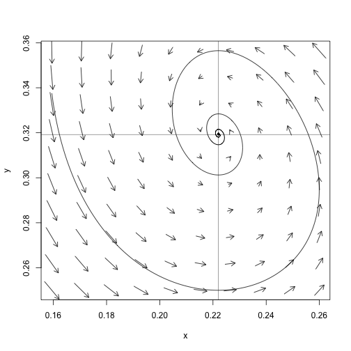

```r
modelI <- TRUE
plotFigure(desolI, parmsI)
```

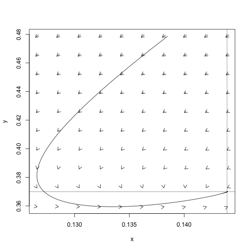

```r
modelI <- FALSE
plotFigure(desolII, parmsII)
```

This examples are both stable, and so verifies the analysis.